# VM 0047 Methodology

## Introduction

Reduce. Reuse. Grow has partnered with the Philippine Eagle Foundation and the Friends of the Usambara to plant over 9 million trees. RRG created a database with pertinent information on each species planted, including relevant cultural significance, practical use, life cycle modeling, and estimated carbon sequestration.

## Methodology

### *Woody Biomass and Change in Carbon Stock (equations 2 and 1)*

a) 2nd Order Polynomial

Where f(x) = DBH (cm)

x = Age (years)

b = constant

2) 3<sup>rd</sup> Order Polynomial

Where f(x) = DBH (cm)

x = Age (years)

b = constant

3) Logarithmic

Where f(x) = DBH (cm)

x = Age (years)

b = 10

a = 0.5

4. Power

Where f(x) = DBH (cm)

x = Age (years)

b = 10

a = 0.5

5) Chapman Richards

Where f(x) = DBH (cm)

t = Age (years)

a= upper asymptote or maximum DBH growth

k= 0.3

b= 1 (can be 0-2.5)

### *Model Details*

To create the most robust dataset, when there were multiple species within the same genus, RRG chose to model these data points together. Individual species models were compared for prediction size (DBH) and statistical result (R2 test). RRG selected the most accurate result (highest R2 value) as the ex-ante estimation of DBH growth. If statistical results were similar, RRG chose the most conservative estimation. Some polynomial and logarithmic models negatively estimated early-stage growth. If these models were still chosen due to conservative estimates, the negative estimations were replaced with 0. A list of models chosen, their justification, statistical results, graphs, and growth predictions can be found on the FRP website.

There was variance in the availability of data points for each species’ model. Some had 10+ datapoints in different age ranges and some only had 4-6 data points. It is commonly known that statistical regression models increase in accuracy with an increase in data availability. Furthermore, some of datapoints were collected in regions outside of the Philippines. Because of this RRG chose a large uncertainty deduction to account for the non-robust dataset. RRG and PEF will need to inventory each species throughout the project duration to update the model and ensure accuracy. Below is a graph of the model for the species *Agathis philippinesis.*

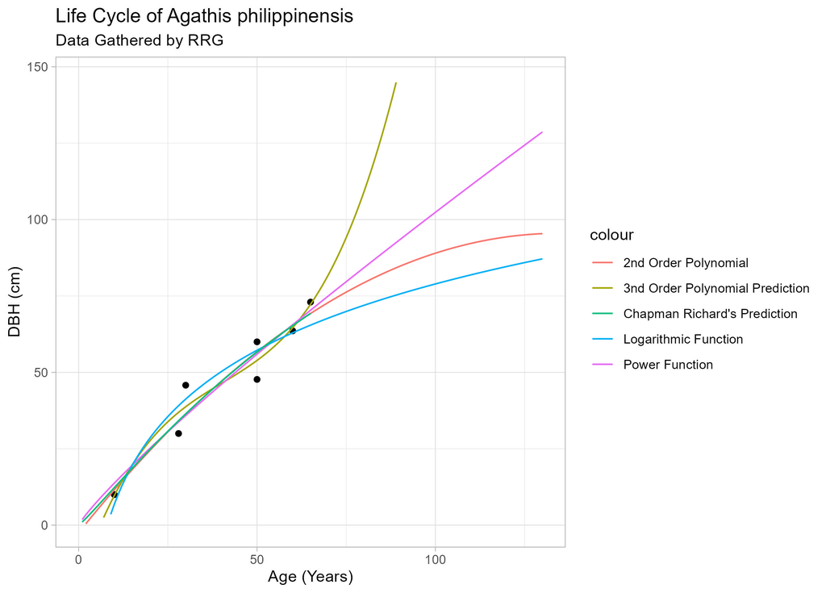

Lifecycle for *A. philippinensis.*

### *Species Filter for Average DBH Growth*

RRG maintains a spreadsheet with chosen species growth models. PEF is implementing three unique planting methodologies with distinct densities and species composition. RRG filtered the data set for species within each planting methodology. Per equation 2 of the VM 0047 methodology, these unique, smaller datasets were averaged to determine the average growth from years 1-50.

### *Allometric and Carbon Conversion*

Allometric equations were applied, which translated the DBH, in cm, to a mass, in kg. These equations are unique to species and regions of the world. RRG conducted a thorough comparison of allometric equations from scientific journals and the database Glob Allome Tree. RRG compared unique species allometric equations and regional allometric equations. RRG ran both model scenarios and determined the region allometric equation was the most conservative. The chosen equation was found by Kenzo and is as follows:

ABG (kg) = 0.829 * DBH^2

The carbon a tree sequesters (absorbs) is simply a proportion of its total weight. So, the mass of each tree was multiplied by the percent carbon of trees or 0.47. These values were then multiplied by the C to Co2e conversion, or 44/12. This value, of t Co2e from years 0-50, represents equation 1 or the carbon stock change. The spreadsheets for allometric equations, their sources, and average changes in woody biomass are on the FRP website.

### *Performance Benchmark*

The analysis for the performance benchmark can be found in the CCB Document posted on the Verra registry. Because the project is in early stages, RRG assumed a performance benchmark value of 1 or 100% of the modeled growth vs. yield values at full stocking. Upon validation events, RRG will complete the entire methodology.